# Data_Analyst_Job_Postings_Report(1)

**Data Analyst Job Postings Report**

*Salary, experience, and data language requirements by Grace Yuying Gao*

*24<sup>th</sup> May 2026*

**1. Introduction**

This project analyzes a sample of Data Analyst job postings in a job-hunting internet. The goal is to explore how estimated salary relates to the minimum years of experience requested and whether postings mention R, Python, both, or neither as data/programming language requirements.

Before plotting, minimum years of experience was converted to numeric values by LLM, with NA and non-numeric entries treated as missing. Data language labels were standardized to R, Python, Both, and Neither. This project used a multi-step process instead of uploading the entire raw CSV file directly into an AI tool. Large job posting datasets often contain long and unstructured descriptions, which can be difficult for an AI model to process all at once. Because AI tools have context window limits, they may not be able to read or analyze every part of a large dataset accurately.

Breaking the work into smaller steps improves focus and accuracy. For example, first cleaning the data, then extracting years of experience, then identifying programming languages, and finally creating visualizations makes the analysis more organized and reliable. This process also reduces the chance of errors or hallucinations because each task is clearly defined and easier to check. Overall, the multi-step approach helps produce a more transparent and trustworthy analysis.

**2. Data Cleaning Summary Analysis**

| **Metric** | **Value** | **Interpretation** |
| --- | --- | --- |
| Total rows | 400 | The dataset contains 400 Data Analyst job postings. |
| Rows usable for scatter plot | 310 | These rows have both valid salary and numeric minimum experience values. |
| Rows usable for box plot | 400 | All rows have valid salary values, so all postings can be used for the language-salary box plot. |
| Missing/non-numeric Minimum Years Experience | 90 | 90 postings did not have a usable numeric experience value. |
| Missing/non-numeric Median Salary Estimate | 0 | Salary data is complete for all postings. |

*Table 1 Data cleaning summary*

The dataset contains 400 Data Analyst job postings. All 400 rows have valid values for Median Salary Estimate, so the salary variable can be used for the full box plot analysis. This means there is no missing salary data, which is helpful because salary is the main outcome variable in this project.

For Minimum Years Experience, only 310 rows could be used in the scatter plot. There are 90 rows where the minimum years of experience was missing, marked as NA, or contained non-numeric text. This means about 22.5% of the postings could not be included in the experience-versus-salary analysis. As a result, the scatter plot is based on a smaller subset of the data and may not fully represent all job postings in the sample.

| **Data Language Category** | **Number of Postings** | **Percentage of Total** |
| --- | --- | --- |
| R | 15 | 3.75% |
| Python | 59 | 14.75% |
| Both | 71 | 17.75% |
| Neither | 255 | 63.75% |
| **Total** | **400** | **100%** |

The Data Languages variable was successfully standardized into four categories: R, Python, Both, and Neither. The largest category is Neither, with 255 postings, meaning most job descriptions in this sample did not explicitly mention either R or Python. The second largest group is Both, with 71 postings, followed by Python only with 59 postings. The smallest group is R only, with just 15 postings.

This distribution suggests that Python is mentioned more often than R in the job descriptions. Also, more postings mention both R and Python than mention R alone, which may indicate that employers who value R may also expect Python or broader technical skills. However, because the R-only group is very small, any salary comparison involving R should be interpreted carefully.

Overall, the cleaned dataset is suitable for exploratory analysis. The salary data is complete, and the language categories are usable for comparison. The main limitation is the missing experience data, which reduces the sample size for the scatter plot and may affect how strongly we can interpret the relationship between experience and salary.

**3. Analysis of Minimum years of experience vs. median salary estimate**

The scatter plot compares the cleaned minimum years of experience on the x-axis with median salary estimate on the y-axis.

The points show substantial salary variation at similar experience levels, suggesting that experience alone does not fully explain salary differences in this sample. Some higher-experience postings have higher salaries, but the pattern is not strong enough to conclude a clear relationship from this small sample.

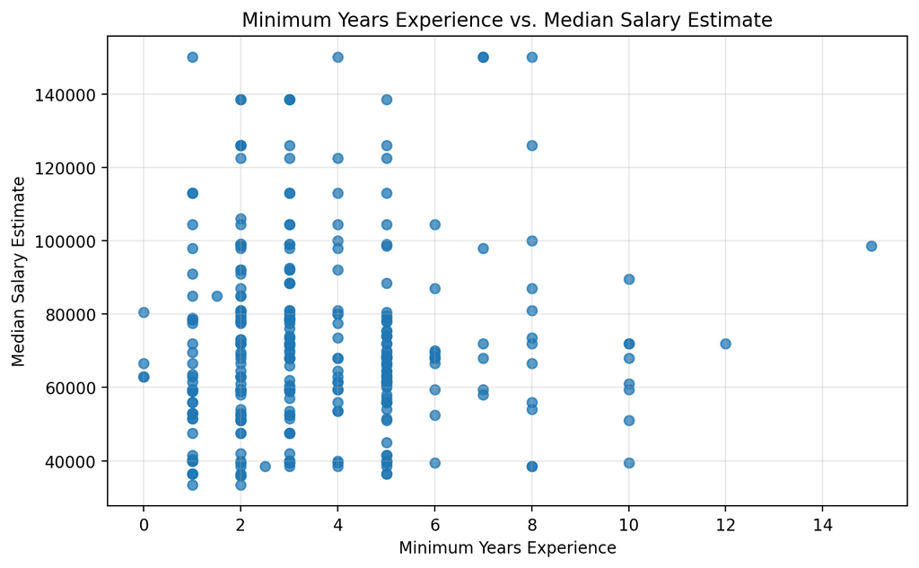

*Figure 1. Scatter plot of cleaned minimum years of experience and median salary estimate.*

**4. Analysis of programming language requirements**

The box plot compares median salary estimates across four data language categories: R, Python, Both, and Neither. The largest group is Neither, with 255 postings, suggesting that many Data Analyst job descriptions in this sample did not explicitly mention either R or Python. The Both category includes 71 postings, followed by Python with 59 postings, while R alone appears in only 15 postings.

In terms of salary, the R-only group has the lowest median salary at approximately $61,500, while the Python, Both, and Neither groups have similar median salaries, around $68,000–$69,000. The Python and Both categories show higher mean salaries than the other groups, partly because they include some high-salary postings up to $150,000. The Both category has the highest mean salary, about $75,655, which may suggest that jobs mentioning both R and Python are associated with somewhat higher salary estimates in this sample.

However, these results should be interpreted cautiously. The sample size is relatively small, especially for the R-only category, and the language categories are based on extracted job description text. Therefore, the differences shown in the box plot are exploratory and should not be interpreted as definitive evidence that one programming language requirement causes higher salaries.

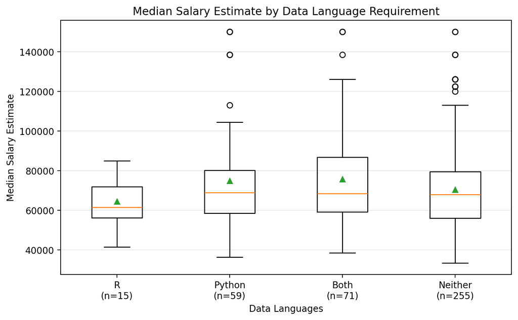

*Figure 2. Box plot of median salary estimate grouped by data language*

**5. Personal Reflection**

This exercise shows how LLM-assisted extraction can turn unstructured job descriptions into analyzable variables under google sheet. It is especially useful for context-sensitive extraction, such as distinguishing the R programming language from unrelated uses of the letter R, including trademarks or abbreviations. However, the extracted variables may still contain errors, so outputs should be reviewed before analysis.

LLMs and AI tools are powerful ,however, they have limitations so, multi-step process should be considered for the data analysis especially with large, unstructured inputs:

- **Context window limits:** LLMs can only process a limited amount of text at once. Large CSV files with long job descriptions may exceed this limit, causing the model to miss or ignore information.
- **Focus and accuracy:** Asking an LLM to clean, extract, analyze, and visualize a large raw dataset all at once can lead to errors, confusion, or hallucinations.

The sample size is limited, the postings may not represent the broader data analyst labor market, and salary estimates can vary by location, company size, industry, and seniority. A larger dataset with validated extraction rules would be needed for stronger conclusions.